# Financial Data Project: Forecasting Oil Movements with Factors

Dom Owens

03/12/2019

```r
oil_close_data <- read.csv("oil_close_2018.csv") #import data
```

For financial series, we consider the logarithm of the value, since movements tend to occur multiplicitavely. These do not appear to be stationary, so we take differences.

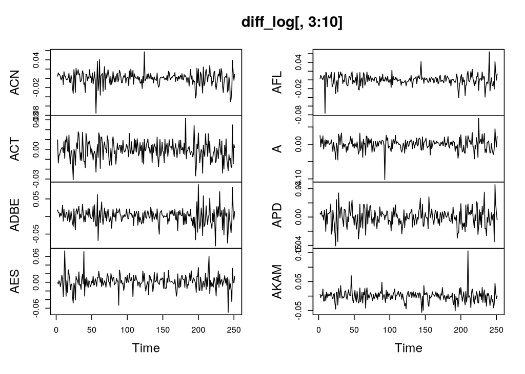

```r
close_data_2018 <- subset(oil_close_data, select = -c(X.1, DATE, DCOILWTICO, ADT)) #drop date and oil, ADT
log_close <- log(close_data_2018) #take log
diff_log <- diff(ts(log_close)) #diff series
plot(diff_log[, 3:10]) #plot first 8 series
```

## Extracting Factors with Principal Components

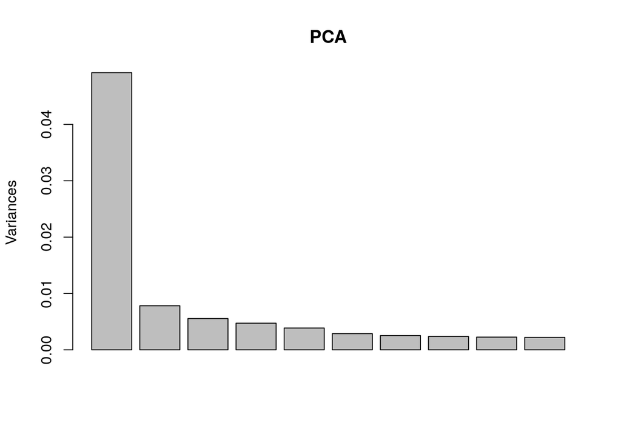

```r
#Covar <- cov(diff_log) #find covariance
#PCA <- princomp(Covar) #take PCA of covariance
PCA <- prcomp(diff_log)
screeplot(PCA)
```

```r
head(PCA$sdev, 30) #view standard deviations of first 30 components
```

```
##  [1] 0.22176908 0.08847104 0.07451144 0.06877110 0.06226909 0.05361267
##  [7] 0.05034662 0.04874833 0.04756765 0.04706843 0.04440906 0.04257630
## [13] 0.04116579 0.04015350 0.03917405 0.03825732 0.03715776 0.03645910
## [19] 0.03583580 0.03514537 0.03488699 0.03442400 0.03424505 0.03375637
## [25] 0.03297181 0.03235025 0.03180969 0.03145715 0.03120196 0.03091355
```

We arbitrarily select the first 10 components.

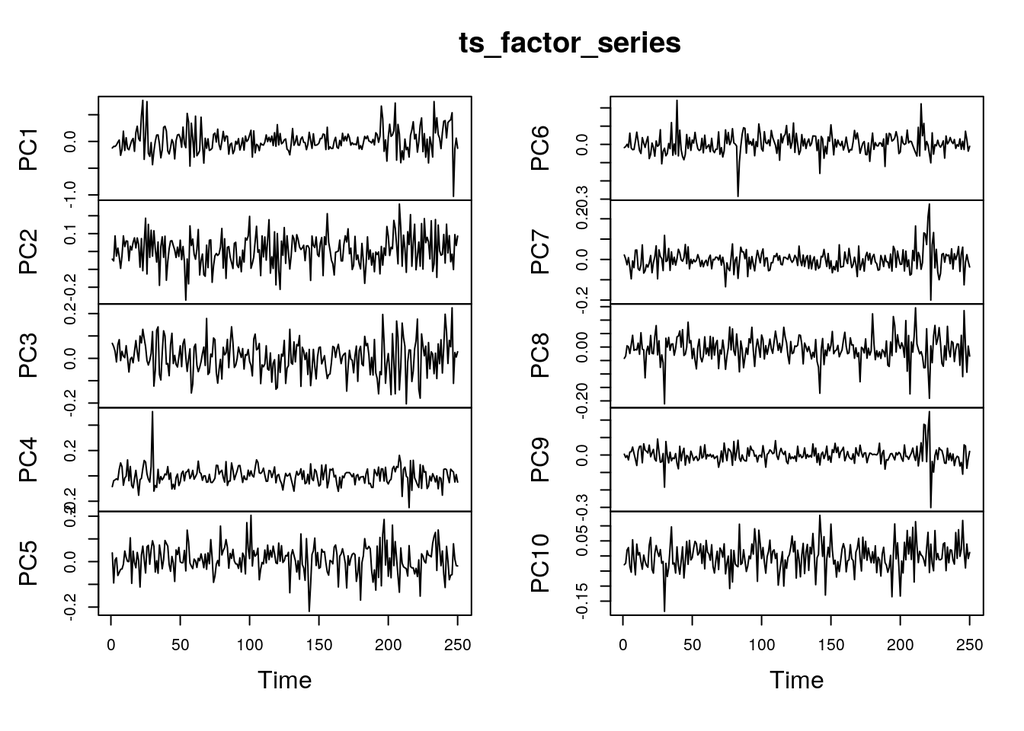

```r
Y <- matrix(diff_log, nrow = dim(diff_log)[1], ncol = dim(diff_log)[2] )
loadings <- PCA$rotation[,1:10]
loadings <- as.matrix(loadings)
factor_series <- (Y%*%loadings) %*% solve(t(loadings)%*%loadings)

ts_factor_series <- ts(factor_series) #isolate as time series
plot(ts_factor_series) #plot factors over time
```

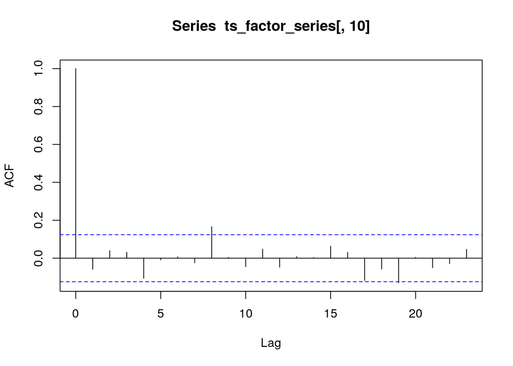

```r
acf(ts_factor_series[,10])
```

# Forecasting oil prices using factors

Suppose we wish to forecast the spot price of a different asset. We might think there is some relationship between the price of crude oil (WTI)[https://fred.stlouisfed.org/series/DCOILWTICO] and the S&P 500; we construct a regression on our factor representation to describe this.

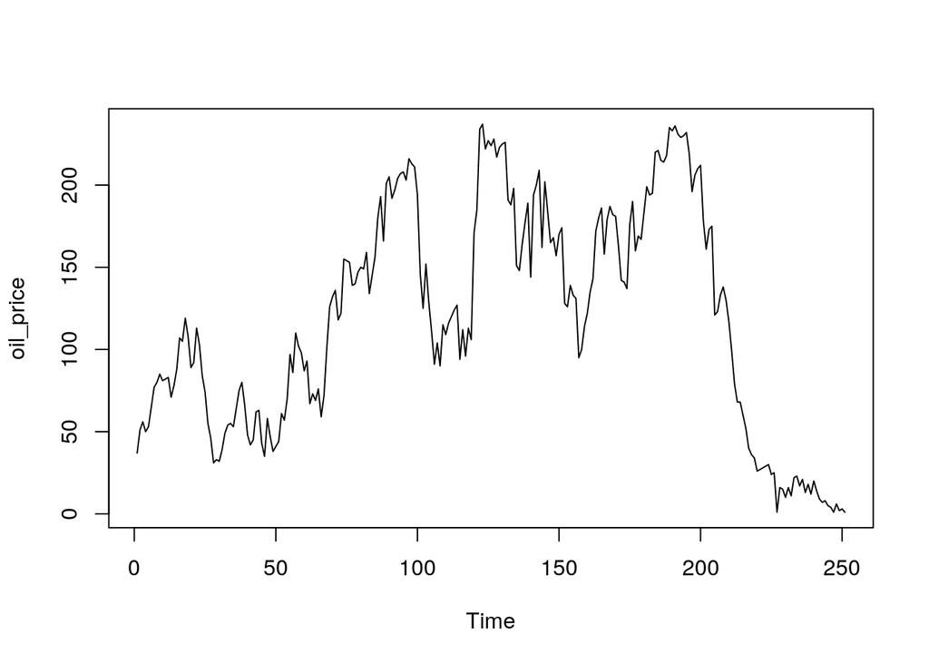

```r
oil_price <- ts(oil_close_data$DCOILWTICO) #select prices
plot(oil_price)
```

Again, this is not stationary and is financial, so we take the log and difference.

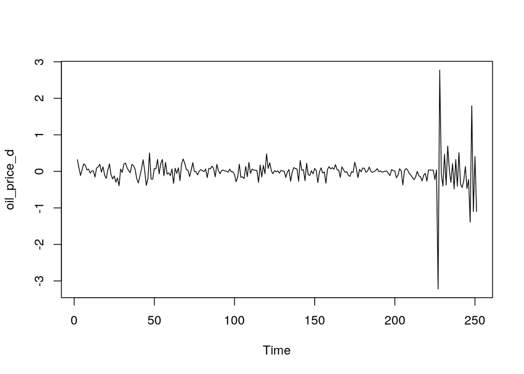

```r
oil_price_l <- log(oil_price) #log series
oil_price_d <- diff(oil_price_l) #difference log series
plot(oil_price_d)
```

We model the differenced log-oil price $y_t$ as a linear function of our factors $\mathbf{f}_t$:
$$y_t = \boldsymbol{\beta}^T \mathbf{f}_t + \epsilon_t$$

```r
model_data <- data.frame(oil = oil_price_d, factor_series )#group series as dataframe
train_data <- model_data[1:200,] #select first 200 as training
test_data <- model_data[201:250,] #select last 250 as testing

oil_model <- lm(oil ~ ., data = train_data, na.action = NULL) #fit linear model

mean(residuals(oil_model)^2) #Mean Squared Error
```

```
## [1] 0.01171531
```

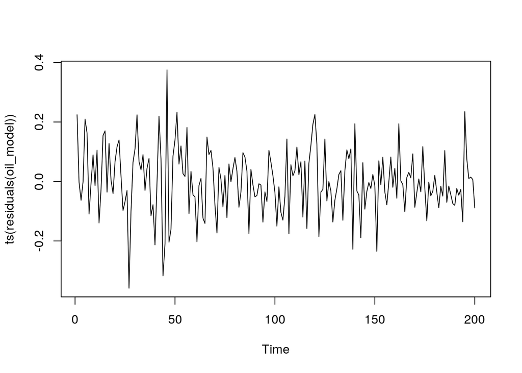

```r
plot(ts(residuals(oil_model))) #residual plot
```

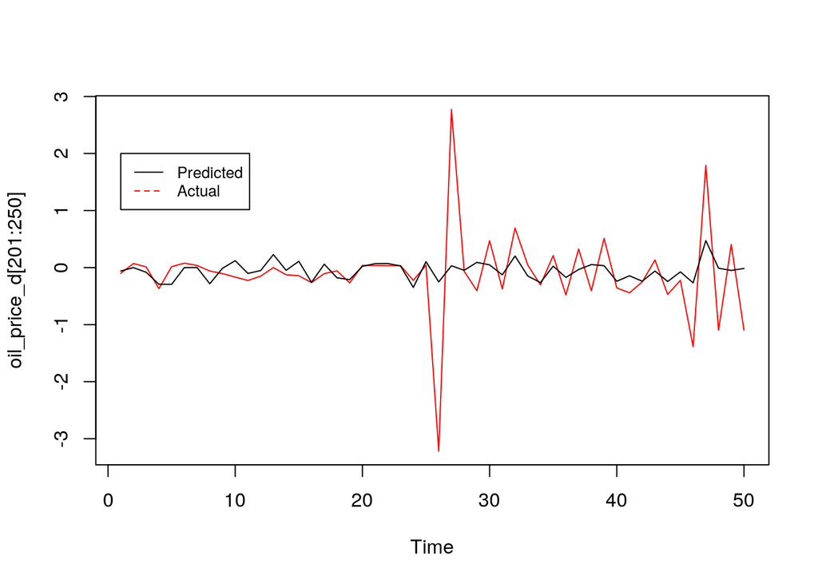

```r
preds <- predict(oil_model,  newdata = test_data)
ts.plot(oil_price_d[201:250], col = "red") #plot predicted series
lines(ts(preds)) #overlay observed series
legend(1, 2,  legend=c("Predicted", "Actual"),
       col=c("black", "red"), lty=1:2, cex=0.8) #add legend
```

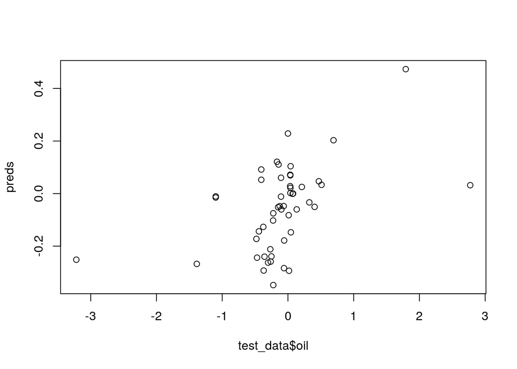

```r
plot(test_data$oil, preds) #scatterplot of prediction errors
```

This performs moderately well in predictive terms, and we can expect prediction inaccuracy of `0.11`. Predicitve power is lost for longer time horizons, though we can see the model at the later time points picks up on the changed volatility.

We inspect the autocorrelation plot.

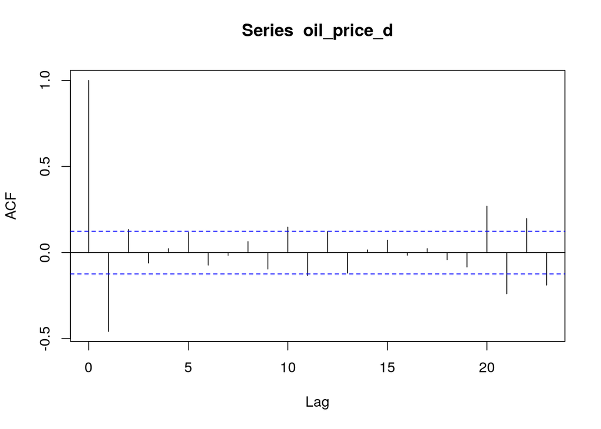

```r
acf(oil_price_d) #plot acf
```

There appears to be a significant autocorrelation with lag 1, so incorporating a temporal dependence component may make the model perform better. We first model a 1-step autoregressive component
$$y_t = \boldsymbol{\beta}^T \mathbf{f}_t + \alpha y_{t-1} + \epsilon_t$$

```r
oil_price_d_lag <- c(oil_price_d[-1],0) #specify 1-lagged series
model_data <- data.frame(oil = oil_price_d, factor_series, lag = oil_price_d_lag) #group series as dataframe
train_data <- model_data[1:200,] #select first 200 as training
test_data <- model_data[201:250,] #select last 250 as testing

oil_MA <- lm(oil ~ ., data = train_data, na.action = NULL) #fit linear model

mean(residuals(oil_MA)^2) #Mean Squared Error
```

```
## [1] 0.01171281
```

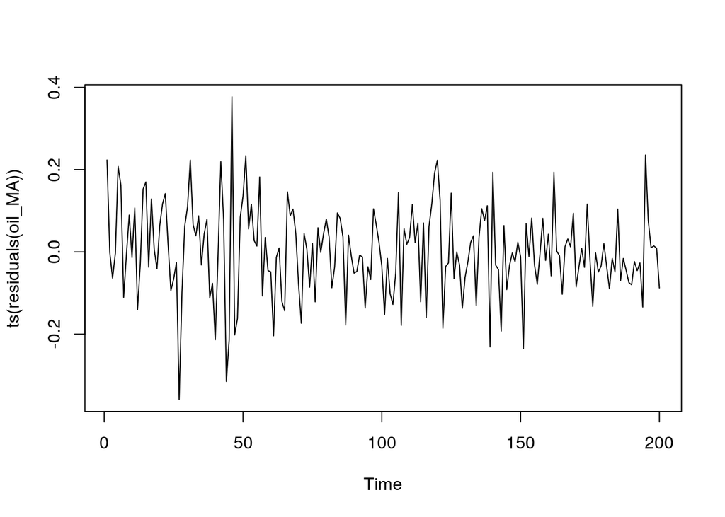

```r
plot(ts(residuals(oil_MA))) #residual plot
```

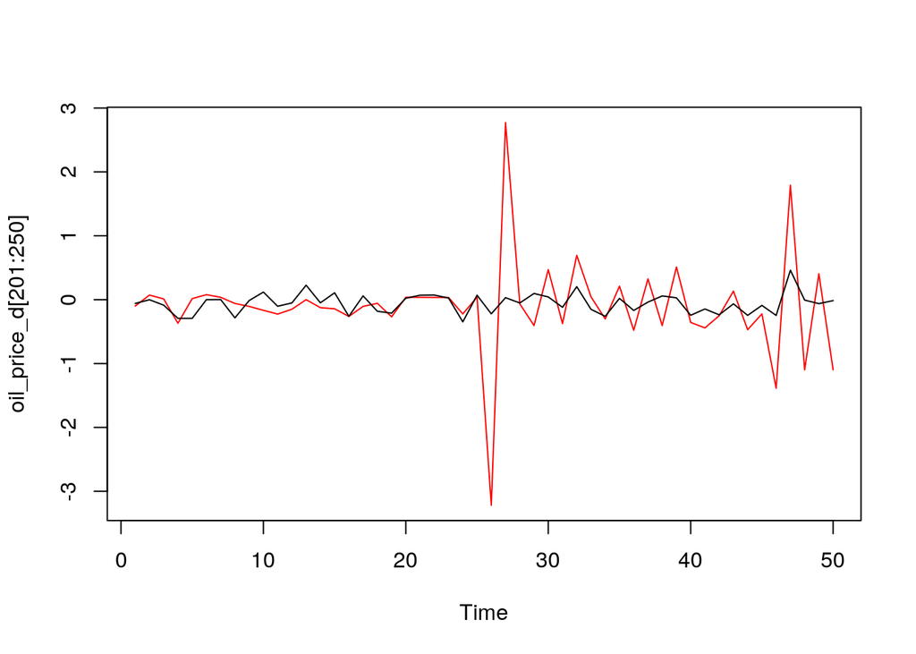

```r
preds <- predict(oil_MA,  newdata = test_data)
ts.plot(oil_price_d[201:250], col = "red") #plot observed series in red
lines(ts(preds)) #overlay predicted series
```

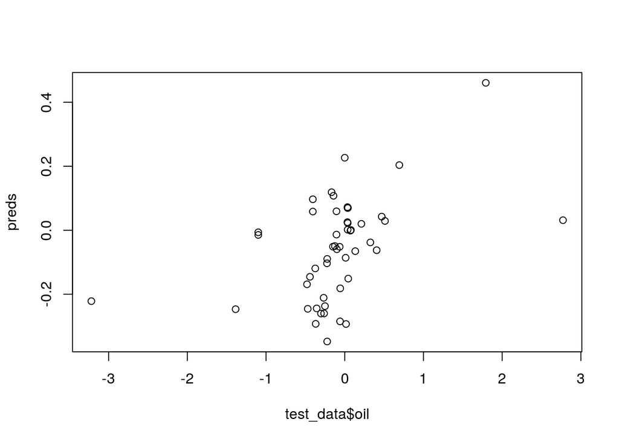

```r
plot(test_data$oil, preds) #scatterplot of prediction errors
```

This does not seem to give us much improvement - here our expected error is similar.

# Classifying Movements with Factors

We might find more luck in classifying whether the log-oil price increases $(+1)$ or decreases $(-1)$. We encode the changes as $y \in \{ -1, +1\}$ depending on their sign, and use the same covariates as in the last problem, incorporating a 1-step lag term. Here, we implicitly ignore our belief that the data are not IID - this is a strong assumption to place on the data, and may affect both the validity and the performance of the model.

## Support Vector Machines

```r
change <- as.numeric(sign(oil_price_d)) #encode change as +1 or -1
lag_change <- as.numeric(sign(oil_price_d_lag)) #encode lag series
model_data <- data.frame(change = change, factor_series, lag_change = lag_change) #group series as dataframe
train_data <- model_data[1:200,] #select first 200 as training
test_data <- model_data[201:250,] #select last 250 as testing
```

We use the `SVM` function from our package.

We aim to find a classification function $f(\boldsymbol{x,\beta},\alpha)$ by minimising
$$|| (\boldsymbol{\beta}^T, \alpha) ||^2 + \sum_t e_t$$
such that
$$\forall t, y_t((\boldsymbol{\beta}^T, \alpha)(\mathbf{f}_t, y_{t-1})^T ) + e_t \geq 1, e_t \geq 0$$

where $e_t$ is the distance of the point $(\mathbf{f}_t, y_{t-1})$ into the margin.

```r
w <- SVM(X = train_data[,-1], y = train_data$change, max_it = 1e3, eta_0 = 1, alpha = 0.9, c = 0.9) #fit SVM
w #print coefficients
```

```
##  [1] -0.0872114540  0.0320566755 -0.0050819883 -0.0017528120 -0.0069442827
##  [6]  0.0013400742 -0.0009593452  0.0010008495  0.0010875899 -0.0051761902
## [11] -0.0392256092
```

```r
SVM_preds <-  as.matrix(test_data[,-1]) %*% w
head(sign(SVM_preds))
```

```
##     [,1]
## 201   -1
## 202   -1
## 203    1
## 204   -1
## 205   -1
## 206   -1
```

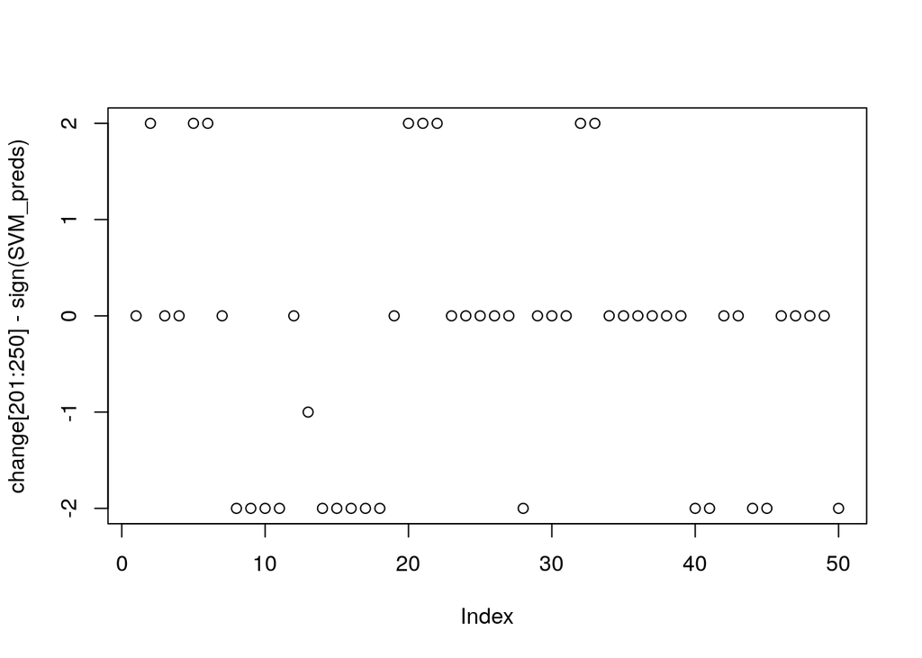

```r
plot(change[201:250] - sign(SVM_preds)) #plot class residuals over time
```

```r
sum(change[201:250] != sign(SVM_preds))/length(SVM_preds) #calculate percentage of misclassified points
```

```
## [1] 0.48
```

This method does not perform particularly well, and is likely no better than classifying with a simple $Y \sim Bernoulli(0.5)$ assignment.

## Bibliography

Manel Youssef & Khaled Mokni, 2019. “Do Crude Oil Prices Drive the Relationship between Stock Markets of Oil-Importing and Oil-Exporting Countries?,” Economies, MDPI, Open Access Journal, vol. 7(3), pages 1-22, July.

Pattern Recognition and Machine Learning, Christopher Bishop

Principal Components Analysis, Ian T. Jolliffe